# 4-4 SVM

### Lagrange function & Lagrange Primal/Dual

양의 클래스: $w^Tx + b \ge 1$,

음의 클래스: $w^Tx + b \lt -1$

위 조건들을 충족시면서 $\frac{1}{2}||w||_2^2$ 최소점을 찾는 것은 어렵습니다.

w의 최적점은 목적 함수에 의해 정해지는 결정되는 게 아니라 조건에 의해 결정됩니다.

조건들에서 w를 도출하기 위한 방향성을 직접 추출하기가 어렵기 때문입니다.

문제를 풀 수 있는 형태, 즉 조건에서 w의 방향성을 구할 수 있는 형태, 바꾸어 가기 위해 사용된 개념이 Lagrange Primal / Dual 입니다.

#### Lagrange Primal

부등식 제약 조건이 있는 최적화 문제를 부등식 제약을 목적함수에 포함시키는 방식으로 문제로 바꿉니다.

> $f_t(\theta)\ge0, i = 1,... n$ 일 때,

> $J(\theta)$를 최소화

Lagrange function을 $\theta$에 대해서는 최소화하고, $\alpha_i$에 대해서는 최대화하는 문제로 바꾸어,

최적화 과정에서 제약 조건이 충족되도록 형태를 바꿉니다.

> $L(\theta, \alpha)=J(\theta) - \sum_{i=1}^n\alpha_i f_t(\theta)$ : **Lagrange function**

> $max_{\alpha} \left(min_{\theta} L(\theta, \alpha)\right)$

> Lagrange multiplier: $\alpha_i$, $\alpha_i \ge 0$, i=1,…,n

이러한 형태의 문제를 Lagrangian Primal 이라고 합니다.

#### Lagrange Dual

최소화와 최대화 동시에 두 개의 최적화 과정이 있으므로, 이 또한 어렵습니다.

아래의 KKT(Karush-Kuhn-Tucker) 조건을 충족시키면,

$\theta$에 대한 최소화 요건은 $\alpha_i$에 대한 최대화 문제로 바꿀 수 있습니다.(Lagrangian Dual)

> 1. $\frac{\partial{L(\theta, \alpha)}}{\partial\theta}=0$
> 2. $f_i(\theta) \ge 0, i=1, ... n$
> 3. $\alpha_i \ge 0, i=1, ... n$
> 4. $\alpha_if_t(\theta) = 0, i=1, ... n$
1. 2. 3. 4. 만족한다면,

> $max_{\alpha} \left(L(\theta, \alpha)\right)$

[output not shown]

최대 마진 분류기의 학습은 선형으로 분리가 가능한 분류 데이터셋에 대해서만 가능합니다.

이러한 한계점을 극복하기 위해 두 가지 접근법을 사용합니다.

1. 분리가 가능하지 않는 데이터에서도 적용할 수 있도록 다음 분리 조건에 대한 완화

> 모든 i에 대해 $y_i(w^Tx_i + b) \ge 1$ 일 때 ($y_i \in \{-1, 1\}),$
2. 분리가 되도록 데이터를 변형하는 방법

첫 번째 접근법이 **소프트 마진 분류기**이고, 두 번째 접근법이 **커널 함수**를 통한 고차원 벡터로 변환하는 방법입니다.

## 3. 소프트 마진 분류기

최대 마진 분류기에서 아래와 같이

> 모든 i에 대해 $y_i(w^Tx_i + b) - 1 + \xi_i \ge 0$ 일 때, ($y_i \in \{-1, 1\}),$

> 모든 i에 대해 $\xi_i \ge 0$

> $\frac{1}{2}||w||_2^2 + C\sum_{i=1}^n\xi_i$를 최소화

Langrangian Primal은

> $L(w, b, \xi, \alpha, \gamma) = \frac{1}{2}||w||_2^2 + C\sum_{i=1}^n\xi_i - \sum_{i=1}^n\alpha_i\left(y_i(w^Tx_i + b) - 1 + \xi_i\right) - \sum_{i=1}^n\gamma_i\xi_i$

> $max_{\alpha, \gamma}min_{w, b, \xi}\left(L(w, b, \xi, \alpha, \gamma)\right)$

> $\alpha_i \ge 0$, i=1,…,n, $\gamma_i \ge 0$, i=1,…,n

Langrangian Dual를 적용합니다.

KKT 조건은

> $\frac{\partial{L(w, b, \xi, \alpha, \gamma)}}{\partial{w}} = 0$

> $\frac{\partial{L(w, b, \xi, \alpha, \gamma)}}{\partial{b}} = 0$

> $\frac{\partial{L(w, b, \xi, \alpha, \gamma)}}{\partial{\xi_i}} = 0$ — (10)

> $y_i(w^Tx_i + b) - 1 + \xi_i \ge 0, i=1, ... n$

> $w = \sum_{i=1}^n\alpha_iy_ix_i$

> $\alpha_i \ge 0, i=1, ... n$

> $\alpha_i\left(y_i(w^Tx_i + b) - 1 + \xi_i \right) = 0, i=1, ... n$

> $\gamma_𝑖\xi_𝑖 = 0, i=1, ... n$

(10)에서 $\alpha_i = C - \gamma_i$ 가 유도됩니다.

$\gamma_i > 0$이면 $\xi_i = 0$이 될 수 있습니다. 하지만 $\gamma_i = 0$ 이면, $\xi_i > 0$ 입니다.

여기서 아래와 같은 관계가 유도가 됩니다.

> $\alpha_i = 0$ 이면 $\gamma_i = C, \xi_i = 0$ 인 최대 마진 바깥 쪽의 데이터 입니다.

> $0 < \alpha_i < C$ 이면 $\gamma_i > 0, \xi_i = 0$ 인 최대 마진 위의 점인 **Support Vector** 입니다..

> $\alpha_i = C$ 이면 $\gamma_i = 0, \xi_i > 0$ 인 최대 마진 안 쪽에 점인 **Support Vector** 입니다..

이로써 SVM의 학습은 최적의 $\alpha_i, i = 1, ... n$를 구하는 문제가 됩니다.

> $L(\alpha) = max_{\alpha} \left(\sum_{i=1}^n\alpha_i - \frac{1}{2}\sum_{i=1}^n\sum_{j=1}^n\alpha_i\alpha_jy_iy_jx_i^Tx_j\right)$

where,

> $\sum_{i=1}^n\alpha_iy_i = 0$

> $w = \sum_{i=1}^n\alpha_iy_ix_i$

> $y_i(w^Tx_i + b) - 1 + \xi_i \ge 0, i=1, ... n$

> $0 \le \alpha_i \le C , i=1, ... n$

> $\alpha_i\left(y_i(w^Tx_i + b) - 1 + \xi_i\right) = 0, i=1, ... n$

## 4. 커널(Kernel)

데이터를 고차원 공간으로 매핑하여 선형 분리 가능한 상태로 변환하는 함수입니다.

예) $x_1, x_2$ → $x_1, x_2, x_1x_2, x_1^2, x_1^2$

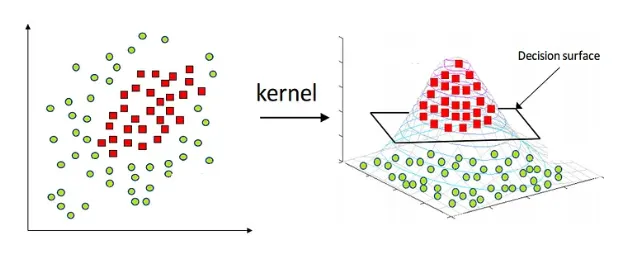

image.png

※이미지 출처: https://medium.com/@Suraj_Yadav/what-is-kernel-trick-in-svm-interview-questions-related-to-kernel-trick-97674401c48d

이러한 고차원 공간의 매핑은 변수의 수가 많아질 수록, 파생되는 변수의 수는 훨씬 많아집니다. 이에 대응하기 위해 커널 트릭(kernel trick)이 사용됩니다. 이를 이용하면 직접 고차원 매핑 변수를 만들지 않아도 커널을 적용할 수 있습니다.

#### 커널 트릭(Kernel trick)

학습과 예측에 필요한 것은 입력 데이터 전체가 아니라 입력 데이터의 내적($x_i^Tx_i$) 입니다.

- 학습시,

> $L(\alpha) = max_{\alpha} \left(\sum_{i=1}^n\alpha_i - \frac{1}{2}\sum_{i=1}^n\sum_{j=1}^n\alpha_i\alpha_jy_iy_jx_i^Tx_j\right)$
- 예측시,

> $w = \sum_{i=1}^n\alpha_iy_ix_i$

> $f(x) = w^Tx + b$

이점에 착안하여, 내적하기 전에 고차원 매핑 변수를 만드는게 아니라,

내적한 값에 Kernel 함수를 적용하여 고차원 매핑효과를 얻는 것을 이용합니다.

가령,

$\mathbf{a} = \begin{bmatrix} a_0 \\ a_1 \\ \vdots \\ a_n \end{bmatrix}$, $\mathbf{b} = \begin{bmatrix} b_0 \\ b_1 \\ \vdots \\ b_n \end{bmatrix}$

$a^Tb = (a_0b_0 + a_1b_1 + ... + a_nb_n)$ 입니다.

$\phi(x)$를 2차 동차 다항 변환이라면,

$\mathbf{\phi(a)} = \begin{bmatrix} a_0^2 \\ a_0a_1 \\ \vdots \\ a_n^2 \end{bmatrix}$, $\mathbf{\phi(b)} = \begin{bmatrix} b_0^2 \\ b_0b_1 \\ \vdots \\ b_n^2 \end{bmatrix}$

$\phi(a)^T\phi(b) = (a_0^2b_0^2 + a_0a_1b_0b_1 + ... a_n^2b_n^2)$

$\left(a^Tb\right)^2 = (a_0b_0 + a_1b_1 + ... + a_nb_n)(a_0b_0 + a_1b_1 + ... + a_nb_n) = a_0^2b_0^2 + 2a_0a_1b_0b_1 + ... + a_n^2b_n^2$

즉, $\phi(x_i^T)phi(x_i)$ → $\phi'(x_i^Tx_i)$ 동일한 효과를 얻을 수 있는 고차항 매핑을 구성할 수 있습니다.

#### 커널(Kernel)의 종류 및 특징

| 커널명 | 커널 함수 | 특징 |
| --- | --- | --- |
| 선형 커널(Linear kernel) | $$x_i \cdot x_j$$ | SVM 모델은 선형의 결정 함수로 나타낼 수 있습니다. |
| 동차 다항 커널(Homogeneous polynomial kernel) | $$\left(x_i \cdot x_j\right)^d$$ | 모든 항의 차수가 d인 다항 변환이 됩니다. |
| 비동차 다항 커널(Inhomogeneous polynomial kernel) | $$\left(x_i \cdot x_j + r\right)^d$$ | 항의 차수가 d보다 작은 다항 변환이 됩니다. |
| 가우시안 방사 기저 함수 커널(Gaussian Radial Base Function kernel) | $$exp^{-\gamma\|\|x_i - x_j\|\|^2}, \gamma > 0, 주로 \gamma=1/(2\sigma^2)$$ $\gamma$가 클 수록 복잡한 경계면이 생깁니다. 모델의 편향이 낮아 집니다 | 무한 차수의 다항 커널의 합과 같은 형태의 변환이 됩니다. |
| 시그모이드 함수 커널(Sigmoid function kernel) | $$tanh(\kappa x_i \cdot x_j + c), \kappa > 0, c < 0$$ |  |

#### 커널 함수의 기본 요건

1. 커널 행렬은 양의 준정부호(positive semidefinite, 모든 벡터 z에 대해 $z^TKz \ge 0$)이어야 합니다.
2. Mercer의 정리(Merger’s theorem): 커널 함수 K(x, y) 는 다음과 같은 수식을 만족합니다.

> $\int_{X \times X} |K(x, y)|^2 \, d\mu(x) \, d\mu(y) < \infty$

**[Ex.2]**

```r
library(e1071)

# SVM 모델 학습
C <- 1e5 # 선형 분리가 가능한 경우이므로 임의의 큰 수를 주었고, 최대한 분리해봅니다.
svm_model <- svm(Class ~ x1 + x2, data = df_toy, type = 'C-classification', kernel = 'linear', cost = C)

# 모델 결과 확인
print(svm_model)
```

```
Call:
svm(formula = Class ~ x1 + x2, data = df_toy, type = "C-classification", kernel = "linear",
    cost = C)


Parameters:
   SVM-Type:  C-classification
 SVM-Kernel:  linear
       cost:  1e+05

Number of Support Vectors:  2
```

```r
summary(svm_model)
```

```
Call:
svm(formula = Class ~ x1 + x2, data = df_toy, type = "C-classification", kernel = "linear",
    cost = C)


Parameters:
   SVM-Type:  C-classification
 SVM-Kernel:  linear
       cost:  1e+05

Number of Support Vectors:  2

 ( 1 1 )


Number of Classes:  2

Levels:
 -1 1
```

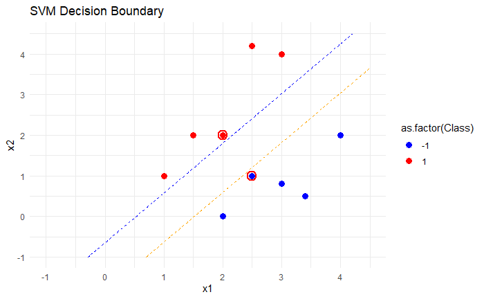

```r
# 결정 경계를 시각화하기 위해 예측 값 계산
x1_range <- seq(-1, 4.5, by = 0.02)
x2_range <- seq(-1, 4.5, by = 0.02)
grid <- expand.grid(x1 = x1_range, x2 = x2_range)
decision_values <- predict(svm_model, grid, decision.values = TRUE)
decision_values <- attributes(decision_values)$decision.values

# 데이터프레임 생성
grid$decision <- decision_values

# ggplot2를 사용하여 시각화
ggplot() +
  geom_point(data = df_toy, aes(x = x1, y = x2, color = as.factor(Class)), size = 3) +
  scale_color_manual(values = c("-1" = "blue", "1" = "red")) +
  geom_contour(data = grid, aes(x = x1, y = x2, z = decision), bins = 1, color = "black", linetype = "solid") +
  geom_contour(data = grid, aes(x = x1, y = x2, z = decision), breaks = 0.75, color = "blue", linetype = "dashed") +
  geom_contour(data = grid, aes(x = x1, y = x2, z = decision), breaks = -0.75, color = "orange", linetype = "dashed") +
  geom_point(data = df_toy[svm_model$index, ], aes(x = x1, y = x2), shape = 1, size = 4, color = "red", stroke = 1.5) +
  xlim(-1, 4.5) +
  ylim(-1, 4.5) +
  labs(title = "SVM Decision Boundary", x = "x1", y = "x2") +
  theme_minimal()
```

**[Ex_3]**

아래 코드는 원형의 결정 경계면을 갖는 데이터를 만듭니다. Linear Kernel과 2차 동차 다항 커널의 분류결과를 비교해봅니다.

비교는 accuracy로 합니다.

```python
from sklearn.datasets import make_circles
from sklearn.model_selection import train_test_split

X_circle, y_circle = make_circles(n_samples=100, factor=0.3, noise=0.05, random_state=123)
```

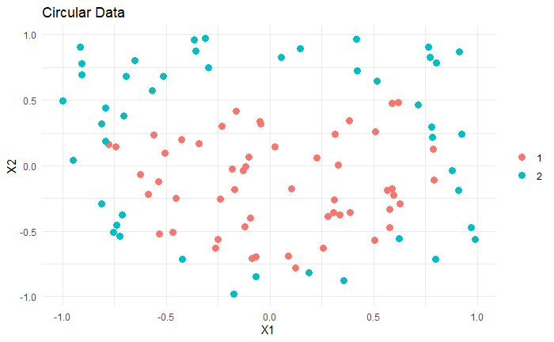

```r
library(mlbench)

# 원형 데이터 생성
set.seed(123)
circle_data <- mlbench.circle(100, d=2)
X_circle <- circle_data$x
y_circle <- circle_data$classes

# 데이터프레임으로 변환
df_circle <- data.frame(X1 = X_circle[, 1], X2 = X_circle[, 2], Class = as.factor(y_circle))

# 시각화
ggplot(df_circle, aes(x = X1, y = X2, color = Class)) +
  geom_point(size = 3) +
  theme_minimal() +
  labs(title = "Circular Data", x = "X1", y = "X2") +
  theme(legend.title = element_blank())
```

```r
# 원형 데이터 생성 (이전 코드에서 이어짐)
set.seed(123)
circle_data <- mlbench.circle(100, d=2)
X_circle <- circle_data$x
y_circle <- circle_data$classes

# 데이터프레임으로 변환
df_circle <- data.frame(X1 = X_circle[, 1], X2 = X_circle[, 2], Class = as.factor(y_circle))

# SVM 모델 학습
svm_model <- svm(Class ~ X1 + X2, data = df_circle, type = 'C-classification', kernel = 'linear', cost = 1)

# 예측 수행
pred <- predict(svm_model, df_circle)

# 정확도 계산
accuracy <- mean(pred == df_circle$Class)
accuracy
```

```
[1] 0.69
```

```r
# SVM 모델 학습
svm_model <- svm(Class ~ X1 + X2, data = df_circle, type = 'C-classification', kernel = 'polynomial', cost = 1, degree = 2, coef0 = 0, gamma = 1)

# 예측 수행
pred <- predict(svm_model, df_circle)

# 정확도 계산
accuracy <- mean(pred == df_circle$Class)
accuracy
```

```
[1] 0.93
```

## Support Vector Machine 다중 클래스 분류

Support Vector Machine 분류 모델을 이진 분류만 가능합니다.

이를 다중 분류에 적용하기 위해서는 이진 분류기를 여러 개 만들고, 결과를 종합을 해야 판별 결과를 냅니다.

### One-vs-One

두 개의 클래스로 짝을 지어 이진 분류 모델을 학습합니다. 이진 분류기는 두 개의 클래스를 뽑는 경우의 수 만큼 생깁니다. ($n(n - 1) / 2$, $n$: 클래스 수).

학습한 이진 분류기들로 예측하고 가장 많은 분류를 얻은 클래스를 선정합니다.

동수가 나왔을 경우 분류 마진이 큰 클래스를 선택합니다.

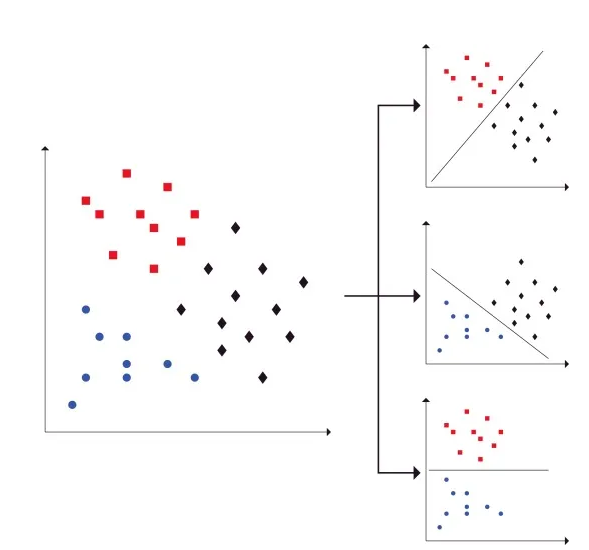

image.png

이미지 출처: https://towardsdatascience.com/multi-class-classification-one-vs-all-one-vs-one-94daed32a87b

### One-vs-Rest

하나의 클래스를 선정하여 Positive 클래스, 나머지를 Negative 클래스로 지정하여, 각 클래스를 한 번씩 Positive 클래스하여 이진 분류 모델을 만듭니다.

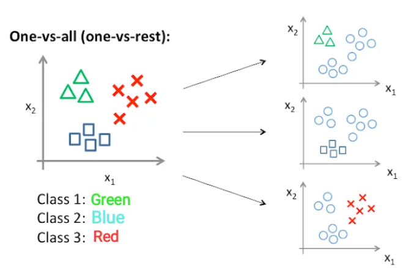

image.png

이미지 출처: https://towardsdatascience.com/multi-class-classification-one-vs-all-one-vs-one-94daed32a87b

## SVM의 장단점

### 장점

- 고차원 공간에서 효과적인 분류를 합니다.
- 분류 마진 최대화를 학습의 목표점을 한다는 점은 보다 좋은 일반화 성능을 기대할 수 있는 근거가 됩니다.
- 커널 트릭을 통한 다양한 유형의 비선형 데이터에 대응이 가능합니다.
- 모델의 복잡도를 제어 가능합니다.

### 단점

- 학습시 복잡한 최적화 과정과, 예측시, Kernel 기반의 SVM은 Support Vector에 비례한 연산 자원이 필요하다는 점에서 계산 비용이 높습니다.
- 모델의 해석이 어렵습니다.